# Complementary analysis

Nicolas Delhomme

2014-11-05

# 1 Setup

Set the working dir

```r
setwd("/mnt/picea/projects/aspseq/asp201/GeneFamily/Run1_TestParameters")
```

Load a library

```r
library(gplots)
```

# 2 Results

Read the file

```r
tab <- read.delim("fusion_ortho-tab.txt")
```

and keep gene families that are found in more than one species but not in all

```r
vals <- tab[,2:5] > 0
sel <- rowSums(vals) > 1 & rowSums(vals) < 4
mat <- vals[sel,]
```

then plot the density of the gene family sizes

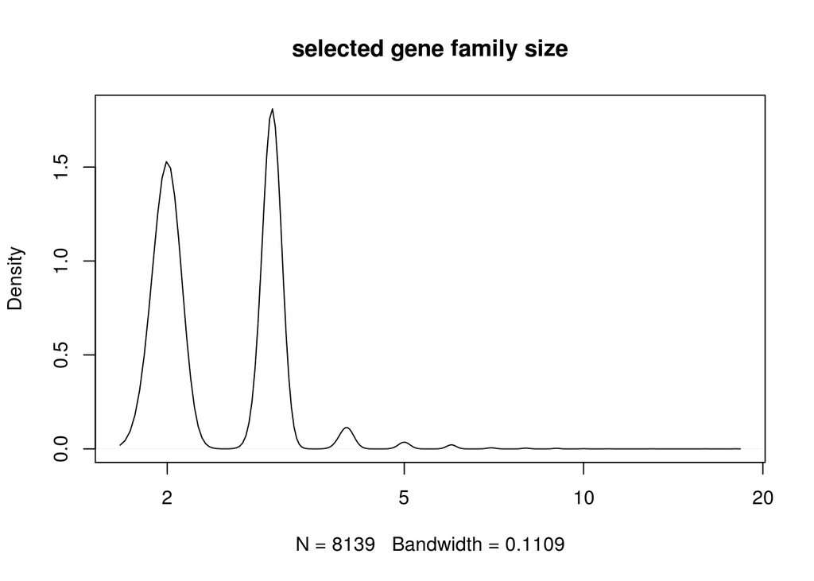

```r
plot(density(tab[sel,"Genes"]),log="x",main="selected gene family size")
```

And use 5 as a cutoff for the total number of genes in that gene family

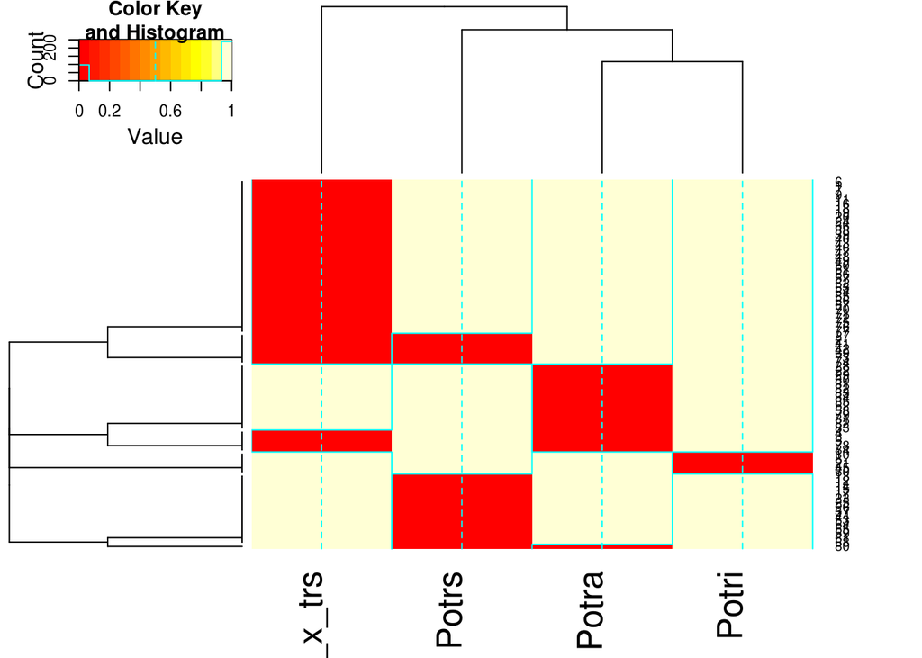

```r
heatmap.2(apply(mat[tab[sel,"Genes"]>5,],2,as.numeric))
```

For interpretation the color code is red=absence, white=presence. I also innacurately use “gene” in the following to describe gene families with genes shared across species. Most of the genes are present in Potri, but for a few that are aspsen specific The hybrid misses a lot of genes otherwise present in Potrs, Potra and Potri. Some more genes are unique to Potri and Potra or Potri and Potrs. Then there are 2 large chunks of genes in the hybrid that are present in Potri but either in Potra or Potrs. Finally a very tiny fraction of genes is only found in Potri and the hybrid.